# ECo 602 - Analysis of Environmental Data

Final Project: Data Analysis

Zachary Bigwood

Fall 2020

# R Markdown Final Demonstration

## The Basics

### How to Create a New R Markdown Notebook

First you need to have RStudio open. Next you need to open the file menu and browse to “New File” and select “RMarkdown..” from that list. This will open the RMarkdown creation prompt where you can specify the title of the document, the author’s name, and the format you want to use.

RMarkdown documents can be used to create webpages that contain R code. This final project is an RMarkdown document itself! The uses are almost limitless.

### Headers

Headers are how we can create new chunks of text with a new title! We can change the size of the headers we want by varying the amounts of # we use. The more #’s you include in your header, the smaller the font size will be.

### Document Text

The text in an RMarkdown document is normal unless it is within a designated code chunk. Text is can be included under the headers easily enough by simply typing what you wish to include. There are no extra fancy steps required here to make the text show up.

### Links and Images

You can easily add links and images to your RMarkdown Document if you choose to do so.

For example, the text we would use to add an image would be as follows: “[alt text][path to the image here]” whereas for a link to a website we simply include the URL within angle brackets and it will be turned into a link.

An example of an image using the "! [] () format:

[figure not shown]

An example of a regular URL link:

https://www.patriots.com/fans/downloads-social-profile

### Making a New Code Chunk and Commenting Code

The shortcut key on Windows is Ctrl - Alt - I

On Mac it is Command - Option - I

If I press this key combo then Rstudio inserts a new code chunk for me

If I want, I can give the chunk a name and it will appear in the navigation pane.

Comments can be added to your code chunks just like normal by using the # symbol.

```
##comments can be added to code chunks by using '#'
```

### Reading a csv file

I’m going to read some data from a csv (comma-separated-values) file.

I can use read.csv() along with the path to the file to read the data into a data.frame.

The functions “require()” or “library()” are included to access the attached packages that are already installed in R. Require is designed to be used within functions and returns a TRUE or FALSE value depending on if the package is found or not. Library would return an error if the package does not exist.

Here’s an example:

```r
require(here)

dat_birds = read.csv(here("data", "hab.sta.csv"))
dat_birds <- read.csv(here("data", "hab.sta.csv"))
```

## Data Structure Functions

We have worked with four different data structures in this class. These structures are vectors, data.frames, matrices, and lists. I will provide brief examples of the follow structures as well as short explanations of what they are.

### Vectors

Vectors are basic data structures that we use in R. They contain elements of the same type and can be logical, integers, double, characters, complex, or raw data.

You can use the function: “typeof()” to figure out what type of vector you are working with in R.

You typically create Vectors using the “c()” function.

```r
#example vector creation

x = c(1,2,3,4,5)

#what type is the vector we just made?

typeof(x)
```

```
## [1] "double"
```

```r
#we can even print that out

print(x)
```

```
## [1] 1 2 3 4 5
```

### Matrices

Matrices are similar to vectors but they contain the dimension attribute. You can check for the attributes of a matrix by using the “attributes()” function. Alternatively you can find the dimension attribute by using the function “dim()”

```r
#creating a matrix

x = matrix(1:6, nrow = 3)

#attributes of the matrix

attributes(x)
```

```
## $dim
## [1] 3 2
```

```r
#dimensions of the matrix

dim(x)
```

```
## [1] 3 2
```

### Lists

A list is a data structure that can have components of all types of mixed data.

The way we can determine if something is a list or a vector is by again using the “typeof()” function.

You can create lists by using the “list()” function in R.

```r
## creating a list

x = list("x" = 2.5, "y" = 7:9, "z" = FALSE)

## checking type of our list

typeof(x)
```

```
## [1] "list"
```

```r
#printing our list

print(x)
```

```
## $x
## [1] 2.5
##
## $y
## [1] 7 8 9
##
## $z
## [1] FALSE
```

### Data Frames

A data frame is made up of different columns containing different things.

You can subset your data frames if you know the name of the columns.

- You can do this by using the ‘$’ symbol and then the name of the column. The return is only the data stored in that column.

```r
#how to build a data frame

frame1 = data.frame(letters = c("a", "b", "c"),
           numbers = c(1, 2, 3))

#you can print the frame by using the print() function

print(frame1)
```

```
##   letters numbers
## 1       a       1
## 2       b       2
## 3       c       3
```

```r
# subset the column by name

frame1$letters
```

```
## [1] "a" "b" "c"
```

### Nrow and Ncol

These two functions return the number of rows and columns present.

Our argument, x, can be a vector, an array, a data frame, or NULL.

```r
#show the number of rows in variable X

x <- matrix(1,2,3,4:10)

nrow(x)
```

```
## [1] 2
```

```r
#show the number of columns in variable X

ncol(x)
```

```
## [1] 3
```

## Subsetting Operators and Functions

Sometimes when we work in R we may need to focus on individual variables of a data set more than others. In this case it would make sense to subset our data so we only get these variables. I’ll be explaining 4 methods of accomplishing this here.

The first example is using brackets to select only a few variables in a data set.

### Single Brackets

```r
#create a new variable to only select the first five variables

newvar = dat_birds[c(1:5)]

#show the head of the new data with only the first five variables

head(newvar)
```

```
##   basin sub sta     lat     long
## 1     D  AL   1 4924418 437009.8
## 2     D  AL   2 4924430 437200.6
## 3     D  AL   3 4924416 437430.8
## 4     D  AL   4 4923998 437731.0
## 5     D  AL   5 4923999 437544.2
## 6     D  AL   6 4924008 437327.2
```

### $

Another method is to use the $ to specify exact variables we want to use in functions. We can also use this to specify ranges of data we want to look at. For example if we were only interested in the birds at basin D we could only call in the data where basin is equal to D.

```r
#only basin D birds

highbirds = dat_birds[which(dat_birds$basin=='D'),]
head(highbirds)
```

```
##   basin sub sta     lat     long elev slope aspect s.id s.edge p.edge p.edge.1
## 1     D  AL   1 4924418 437009.8  542    75     15    3      E      E      131
## 2     D  AL   2 4924430 437200.6  519    80    326    2      E      E      192
## 3     D  AL   3 4924416 437430.8  584    70    230    1      I      I        0
## 4     D  AL   4 4923998 437731.0  612    60    208    3      I      E      120
## 5     D  AL   5 4923999 437544.2  580    43    235    3      I      I        0
## 6     D  AL   6 4924008 437327.2  554    65     60    3      I      E      166
##   p.cwedge ba.con ba.hard ba.snag ba.tot ba.ratio snag.sml snag.ml snag.l
## 1       79      0       5       0      5        0        7       4      0
## 2      175     18       0      18     18      100       67      46     32
## 3        0      0       0       5      0       50       14      11      4
## 4        6      9      14       0     23       40        4       4      4
## 5        0     14       0       0     14      100        0       0      0
## 6        8      9       0       5      9      100       21       7      7
##   snag.dc1 snag.dc2 snag.dc4
## 1        4        0        4
## 2       28       21       18
## 3        0        4       11
## 4        0        0        4
## 5        0        0        0
## 6        7        0       14
```

### Double Brackets

A third method is the double bracket method. This is slightly more nuanced than the single bracket method because it allows for only a single element to be selected using character or integer indices.

I found the information for this method here: https://cran.r-project.org/doc/manuals/R-lang.html#Indexing.

```r
#double brackets allows for specific selection

x = list('one', 'two', 'three')

#comparison between single and double brackets

y = x[1]
class(y)
```

```
## [1] "list"
```

```r
y = x[[1]]
class(y)
```

```
## [1] "character"
```

### Subset

The final subsetting operator is the “subset()” function itself. This function allows us to create a subset of our data to the specifications we set.

```r
#create subset and select variables to keep

dfive = subset(dat_birds, slope > 75 | elev > 500, select = c(basin, aspect, lat, long, elev, slope))
head(dfive)
```

```
##   basin aspect     lat     long elev slope
## 1     D     15 4924418 437009.8  542    75
## 2     D    326 4924430 437200.6  519    80
## 3     D    230 4924416 437430.8  584    70
## 4     D    208 4923998 437731.0  612    60
## 5     D    235 4923999 437544.2  580    43
## 6     D     60 4924008 437327.2  554    65
```

## Numerical Data Exploration

A few of the numerical data exploration functions we talked about during the class were summary, mean, and standard deviation. These functions can all be applied to a dataset or variable and they will give us important information about variables or the data sets themselves

### Summary

Our first function is the summary function. Summary will give us the length, class, and mode of our variables if they are strings or it will determine the min, 1st quartile, median, mean, 3rd quartile and max values if the variable is an intetger. summary can be applied to the data set as a whole or just a few select variables depending on the type of analysis that needs to be done.

```r
#total summary

summary(dat_birds)
```

```
##     basin               sub                 sta             lat
##  Length:1046        Length:1046        Min.   : 1.00   Min.   :4895945
##  Class :character   Class :character   1st Qu.: 9.00   1st Qu.:4905363
##  Mode  :character   Mode  :character   Median :18.00   Median :4928818
##                                        Mean   :17.98   Mean   :4948819
##                                        3rd Qu.:27.00   3rd Qu.:5009357
##                                        Max.   :38.00   Max.   :5020998
##       long             elev           slope            aspect
##  Min.   :426584   Min.   : 85.0   Min.   :  0.00   Min.   :  0.0
##  1st Qu.:431981   1st Qu.:301.0   1st Qu.: 34.25   1st Qu.: 90.0
##  Median :438316   Median :382.0   Median : 50.00   Median :183.0
##  Mean   :440317   Mean   :400.5   Mean   : 50.27   Mean   :182.5
##  3rd Qu.:449337   3rd Qu.:479.0   3rd Qu.: 67.75   3rd Qu.:274.8
##  Max.   :460907   Max.   :872.0   Max.   :110.00   Max.   :360.0
##       s.id           s.edge             p.edge             p.edge.1
##  Min.   : 1.000   Length:1046        Length:1046        Min.   :  0.00
##  1st Qu.: 1.000   Class :character   Class :character   1st Qu.:  0.00
##  Median : 2.000   Mode  :character   Mode  :character   Median :  0.00
##  Mean   : 2.956                                         Mean   : 49.02
##  3rd Qu.: 3.000                                         3rd Qu.:112.75
##  Max.   :24.000                                         Max.   :267.00
##     p.cwedge         ba.con          ba.hard           ba.snag
##  Min.   :  0.0   Min.   :  0.00   Min.   :  0.000   Min.   :  0.00
##  1st Qu.:  0.0   1st Qu.:  4.00   1st Qu.:  0.000   1st Qu.:  0.00
##  Median :  0.0   Median : 12.00   Median :  0.000   Median :  0.00
##  Mean   : 10.3   Mean   : 17.84   Mean   :  4.598   Mean   :  5.16
##  3rd Qu.:  7.0   3rd Qu.: 28.00   3rd Qu.:  5.000   3rd Qu.:  8.00
##  Max.   :196.0   Max.   :129.00   Max.   :184.000   Max.   :138.00
##      ba.tot          ba.ratio         snag.sml         snag.ml
##  Min.   :  0.00   Min.   :  0.00   Min.   :  0.00   Min.   :  0.00
##  1st Qu.:  6.00   1st Qu.: 50.00   1st Qu.:  4.00   1st Qu.:  4.00
##  Median : 18.00   Median :100.00   Median : 21.00   Median : 11.00
##  Mean   : 22.43   Mean   : 75.48   Mean   : 32.63   Mean   : 17.76
##  3rd Qu.: 32.00   3rd Qu.:100.00   3rd Qu.: 46.00   3rd Qu.: 28.00
##  Max.   :207.00   Max.   :100.00   Max.   :393.00   Max.   :141.00
##      snag.l         snag.dc1          snag.dc2         snag.dc4
##  Min.   : 0.00   Min.   :  0.000   Min.   :  0.00   Min.   :  0.00
##  1st Qu.: 0.00   1st Qu.:  0.000   1st Qu.:  0.00   1st Qu.:  0.00
##  Median : 7.00   Median :  0.000   Median :  4.00   Median :  7.00
##  Mean   :10.63   Mean   :  4.942   Mean   : 12.36   Mean   : 15.51
##  3rd Qu.:14.00   3rd Qu.:  4.000   3rd Qu.: 18.00   3rd Qu.: 21.00
##  Max.   :85.00   Max.   :216.000   Max.   :212.00   Max.   :134.00
```

```r
#summary of particular variable

summary(dat_birds$elev)
```

```
##    Min. 1st Qu.  Median    Mean 3rd Qu.    Max.
##    85.0   301.0   382.0   400.5   479.0   872.0
```

### Mean

The second numerical function is the “mean()” function. This function returns an average for whatever range of data we specify.

```r
#mean of the elevation which is a variable in the birds data set

mean(dat_birds$elev)
```

```
## [1] 400.5201
```

```r
#alternatively you can use it to find the mean of a list

x = c(1,2,3,4,5)
mean(x)
```

```
## [1] 3
```

### Standard Deviation

The last numerical function is “sd()” or standard deviation. Like the name suggests it can be used to find standard deviation of whatever we want assuming the values are logical.

```r
#we can use sd() to find the standard deviation of a variable

sd(dat_birds$elev)
```

```
## [1] 144.6148
```

```r
#or we can use it to find the standard deviation of a list

x = c(1,2,3,4,5)
sd(x)
```

```
## [1] 1.581139
```

## Graphical Data Exploration

The next section covers some of the different types of functions that we have used this semester to explore graphical data.

### Histograms

The first of these functions is “par()”. A function that can be used to set graphical parameters by specifying them as an argument or by passing them as a list of tagged values. In class we have used the par function to display multiple plots at once. We can also use “mar” within the “par()” function to create margins if we so choose.

After I subset the data the next function is “main()” which is responsible for changing the title of the graph.

Next, I change the name of the X axis using “xlab()” and change the name of the Y axis by using “ylab()”.

The function “col()” is responsible for changing the color of the histogram boxes. In this case I make the Chinstrap Penguin histogram red and the Adelie Penguin histogram blue.

The “breaks()” function is used to suggest the number of cells for the histogram. R usually treats these as a suggestion so they may not be to your exact specification as is the case in my example. R will set the breakpoints to pretty values on it’s own.

The “xlim()” and “ylim()” functions are used to set the limits of the X axis and Y axis respectively.

The function we can use to scale the text of our symbols or text of our axis is “cex()”. Different variations of this function allow us to scale different things. For example “cex.axis()” is the axis scaler and “cex.main()” is the title scaler.

An example of all of these in use using the palmer penguins data is below.

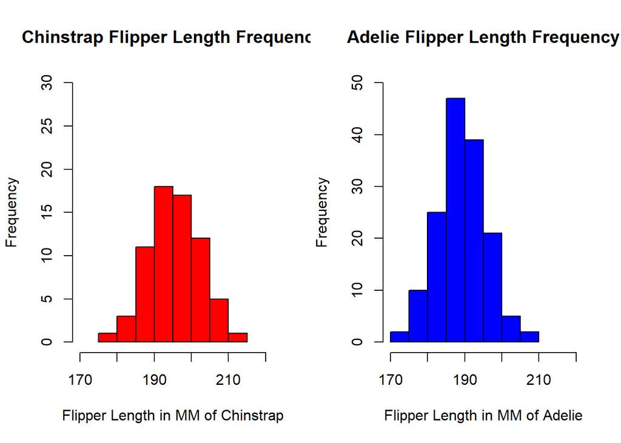

```r
#call palmer penguins

require(palmerpenguins)

#initial subset for the Gentoo penguins

penguin_dat = droplevels(subset(penguins, species != "Gentoo"))

#set the graphs to appear on the same row with 1 per column

par(mfrow = c(1,2))

#specify our two species of penguins into their own subsets

dat_adelie = subset(penguin_dat, species == "Adelie")
dat_chinstrap = subset(penguin_dat, species == "Chinstrap")

#create two histograms with out set parameters.

hgA <- hist(dat_chinstrap$flipper_length_mm, main = 'Chinstrap Flipper Length Frequency', xlab = 'Flipper Length in MM of Chinstrap', ylab = 'Frequency', col = "red", breaks = 5, xlim = c(170, 220), ylim = c(0, 30), cex = 2)
hgB <- hist(dat_adelie$flipper_length_mm, main = 'Adelie Flipper Length Frequency', xlab = 'Flipper Length in MM of Adelie', ylab = 'Frequency', col = "blue", xlim = c(170, 220), ylim = c(0, 50), cex = 2)
```

### Scatterplots

There are many similarities if we were to use the “plot()” function instead of “hist()”. “Plot()” will create scatterplots instead of histograms though.

We can include an additional function, “pch()” which would allow us to specify what point shapes we want to use on our plot.

Here is an example of that using habitat data where I set the pch to be equal to 2 to change our points into triangles.

I also used the required mar argument in my “par()” function.

```r
#set data frame

data_habitat <- read.csv(here("data","hab.sta.csv"))

#create variables from data frame

elev <- data_habitat$elev
slope <- data_habitat$slope
aspect <- data_habitat$aspect
ba <- data_habitat$ba.tot

#par mar to return margins

par("mar")
```

```
## [1] 5.1 4.1 4.1 2.1
```

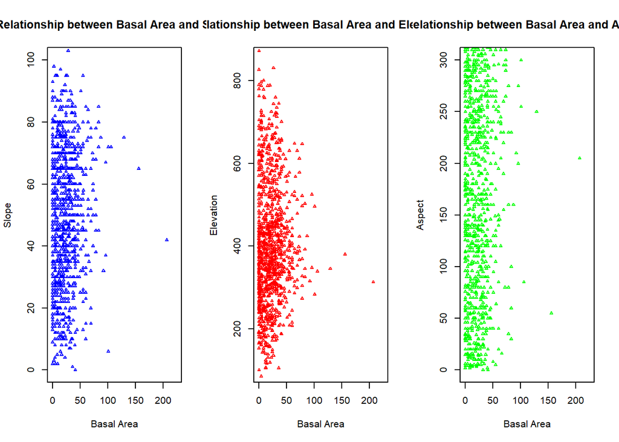

```r
#set parameters: 1 row with 3 graphs across

par(mfrow = c(1,3))

#3 separate graphs with all the required arguments

plot(ba, slope, main = "Relationship between Basal Area and Slope", pch = 2, xlab = "Basal Area", ylab = "Slope", col = "blue", cex = 0.5, xlim = c(0, 225), ylim = c(0, 100))
plot(ba, elev, main = "Relationship between Basal Area and Elevation", pch = 2, xlab = "Basal Area", ylab = "Elevation", col = "red", cex = 0.5, xlim = c(0, 225), ylim = c(100, 850))
plot(ba, aspect, main = "Relationship between Basal Area and Aspect", pch = 2, xlab = "Basal Area", ylab = "Aspect", col = "green", cex = 0.5, xlim = c(0,225), ylim = c(0, 300))
```

### Boxplots

Another of the graphing functions we used this semester was the “boxplot()” function. This function enables us to compare things directly against each other and find out the mean and quartile ranges of a variable by creating a boxplot of the variable.

The function can take in any number of numerical vectors and create a boxplot for each one. We can then compare these directly against each other if we use the “par()” function to set rows beforehand.

Here is an example of the boxplot function in use comparing penguin data.

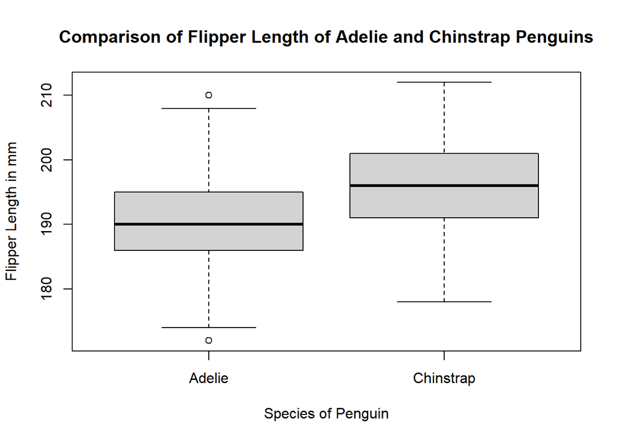

```r
# palmer penguin data again

require(palmerpenguins)

# creating a variable out of a subset of the species of penguin we want to look at.

penguin_dat = droplevels(subset(penguins, species != "Gentoo"))

# creating the boxplot itself and naming our axis and giving it a title

boxplot(flipper_length_mm ~ species, data = penguin_dat, xlab = "Species of Penguin", ylab = "Flipper Length in mm", main = "Comparison of Flipper Length of Adelie and Chinstrap Penguins")
```

## Distribution Functions

This section covers some of the distribution functions we have used this semester.

### Normal Distribution

A few of the functions we worked with this semester generate normal distributions. These functions “dnorm()”, “pnorm()”, and “qnorm()” should create bell shaped curves that give us the mean of the data set with 50% of values on either side of the mean.

We can create some normal distributions using these functions. These normal distributions have some different requirements in order to find the distributions.

“dnorm()” for example needs a vector of numbers, the mean, and the standard deviation. “pnorm()” has the same requirements as “dnorm()” but “qnorm()” needs to have a vector of probabilities, the mean, and the sd in order to find it’s distribution.

We can also set the lower.tail to be false to give us the reverse of what we expect the answer to be.

Below are examples of each function.

#### dnorm()

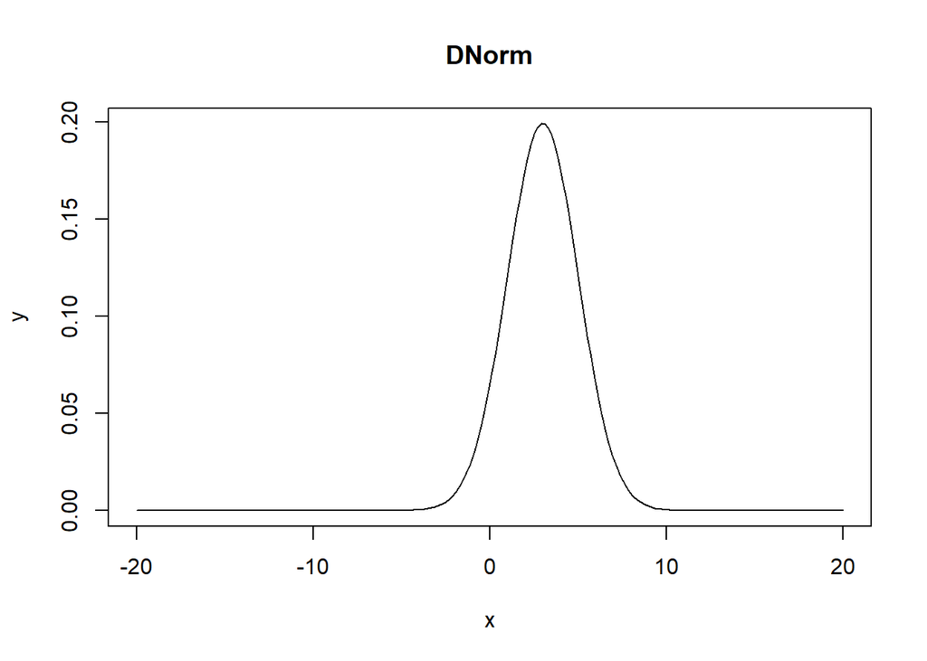

```r
# first we can create a simple sequence to use for our distributions

x = seq(-20, 20, length.out = 200)

# then we can find the normal distribution of our sequence by giving it a mean and using a SD

y = dnorm(x, mean = 3, sd = 2)

#we can then plot our dnorm against our sequence and see the results

plot(x,y, main = "DNorm", type = "l")
```

#### pnorm()

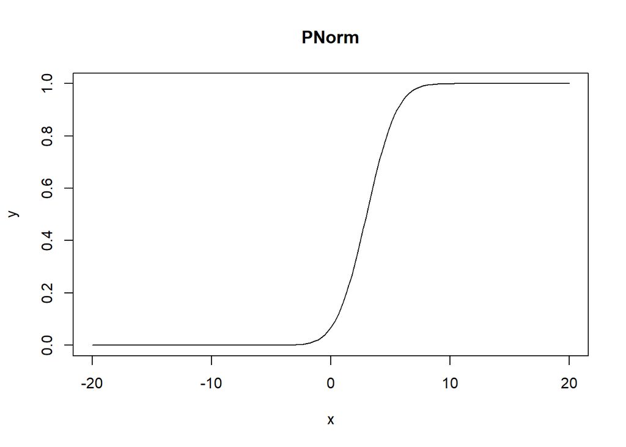

```r
# lets make the sequence again for our vector

x = seq(-20, 20, length.out = 200)

#this time we're going to be using pnorm but with the same mean and sd

y = pnorm(x, mean = 3, sd = 2)

#and we can plot that

plot(x,y, main = "PNorm", type = "l")
```

```r
# we can also use pnorm to find probabilities such as finding the chance to observe value less than 1.2

pnorm(1.2, 2, 2)
```

```
## [1] 0.3445783
```

```r
#as mentioned earlier we can set lower.tail to be false to determine the chance that a value will be greater than 1.2 rather than lower than 1.2

pnorm(1.2, 2, 2, lower.tail = FALSE)
```

```
## [1] 0.6554217
```

#### qnorm()

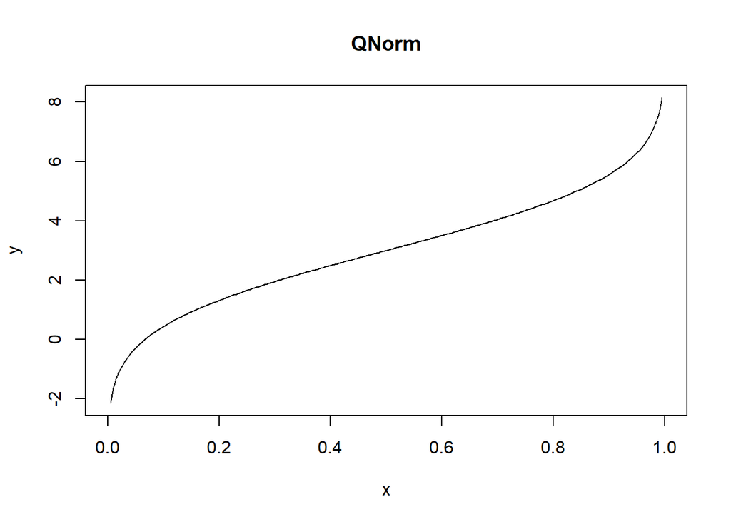

```r
#qnorm is a bit different because we're using probabilities we can still use a sequence though but it has to be between 0 and 1

x = seq(0,1, length.out = 200)

#we can still keep the same mean and sd though

y = qnorm(x, mean = 3, sd = 2)

#and again we can plot it and see what happens

plot(x,y, main = "QNorm", type = "l")
```

### Binomial Distribution

We also worked with a few binomial distribution functions during the semester. These functions were “dbinom()”, “pbinom()”, and “qbinom()”.

Similarly to the normal distributions these functions are similar but not quite the same. “dbinom()” and “pbinom()” require the same parameters, a vector of numbers, the number of trials, and a probability. “qbinom()” requires a vector of probabilities in lieu of a vector of numbers however.

According to https://www.rdocumentation.org/packages/stats/versions/3.3/topics/Binomial, “dbinom()” gives us the density, “pbinom()” gives us the distribution function, and “qbinom()” gives the quantile function under which a given proportion of the binomial population lies.

Below are some examples.

#### dbinom()

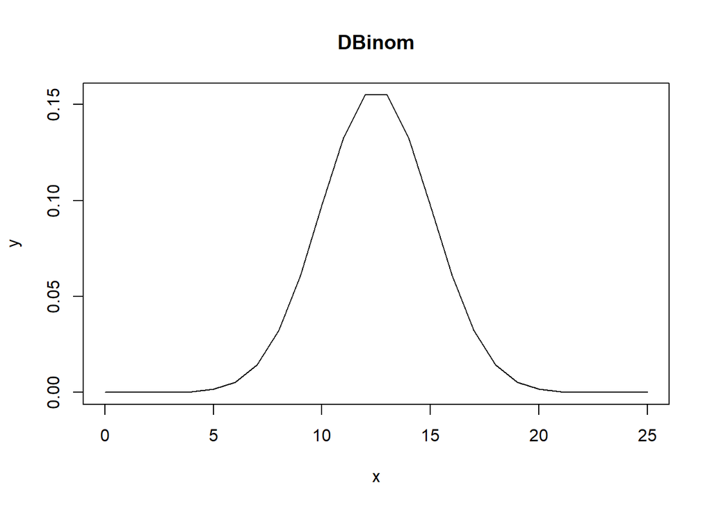

```r
#Keeping with the theme I'm going to use sequences to give us our numbers again. Here I am creating 25 numbers with increments of one

x = seq(0,25, by = 1)

# next I'm going to name the binomial function. We already know our vector of numbers, X. The size is 25 so we can fill that in. For this example probability will be 50%.

y = dbinom(x, 25, 0.5)

#and we can plot our results

plot(x,y, main = "DBinom", type = "l")
```

```r
# we can also use dbinom to find exact counts for example this will find the chance for exactly 3 in pop of 4

dbinom(3, 4, 0.75)
```

```
## [1] 0.421875
```

#### pbinom()

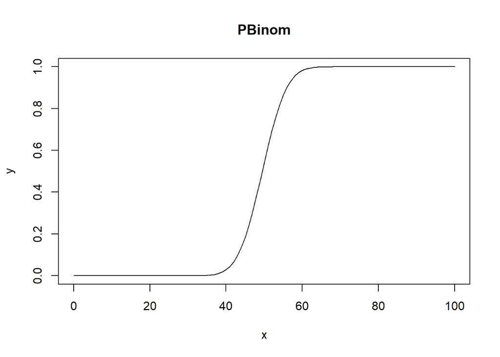

```r
#this function gives us the cumulative probability of an event occuring. an easy example is tossing a coin so lets do that 100 times

x = seq(0,100, by = 1)

#so our size is 100, probability is 50% and we have a number vector to use.

y = pbinom(x, 100, 0.50)

#and we can plot that

plot(x, y, main = "PBinom", type = "l")
```

#### qbinom()

```r
# we can use qbinom to find different quantiles of a distribution. So if a squirrel has a 15% chance of finding it's buried acorn again and it has buried 100 acorns we can find the bottom quantile of that using the following

qbinom(.1, 100, 0.15)
```

```
## [1] 11
```

```r
#this is the amount of acorns we could expect the squirrel to find again given the probabilities.
```

# Part 2: Data Analysis

This section is a complete data anaylsis example usuing the “Delomys” species data.

## Numerical Exploration

A code chunk that contains the function “summary()” used on both body mass and body length data columns.

```r
#open data

require(here)
dat_delomys <- read.csv(here("data", "delomys.csv"))

#summary on body mass and body length

summary(dat_delomys$body_length)
```

```
##    Min. 1st Qu.  Median    Mean 3rd Qu.    Max.
##    49.0   106.0   116.0   114.7   124.0   265.0
```

```r
summary(dat_delomys$body_mass)
```

```
##    Min. 1st Qu.  Median    Mean 3rd Qu.    Max.
##    5.00   35.00   43.00   44.06   54.00  105.00
```

```r
#shapiro test on these to test normality

delomyslength <- dat_delomys$body_length
delomysmass <- dat_delomys$body_mass
delomyssspecies <- dat_delomys$bionmial
shapiro.test(delomysmass)
```

```
##
##  Shapiro-Wilk normality test
##
## data:  delomysmass
## W = 0.99506, p-value = 4.33e-05
```

```r
shapiro.test(delomyslength)
```

```
##
##  Shapiro-Wilk normality test
##
## data:  delomyslength
## W = 0.87609, p-value < 2.2e-16
```

## Graphical Exploration

You can adjust the size of plots by using the two functions “fig.height =” and “fig.width=”

Below I included a few different graphs:

[output not shown]

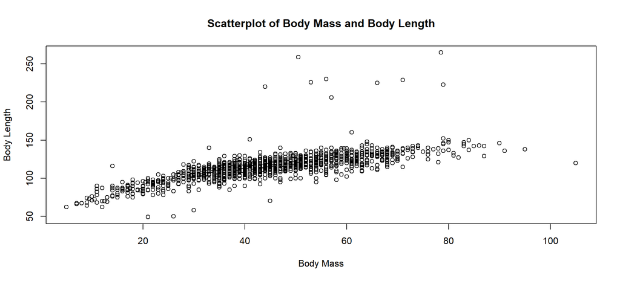

```r
#assorted graphs per the instructions

plot(delomysmass, delomyslength, main = "Scatterplot of Body Mass and Body Length", xlab = "Body Mass", ylab = "Body Length")
```

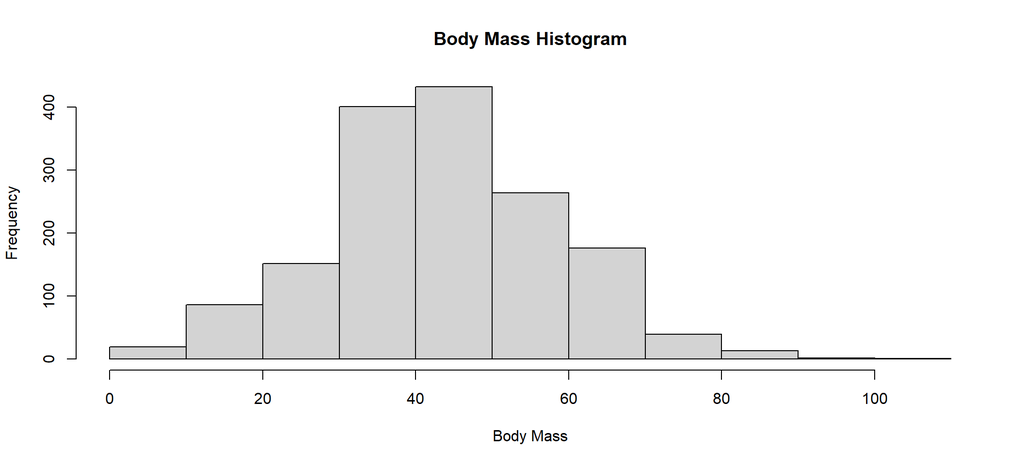

```r
hist(delomysmass, main = "Body Mass Histogram", xlab = "Body Mass")
```

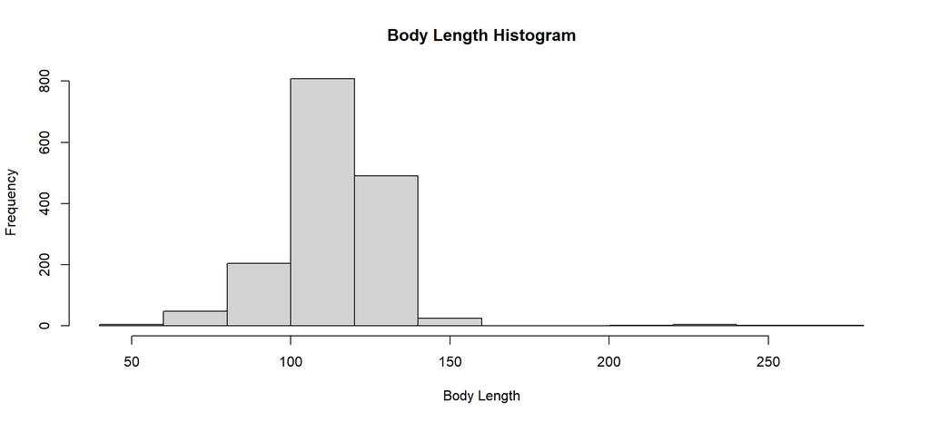

```r
hist(delomyslength, main = "Body Length Histogram", xlab = "Body Length")
```

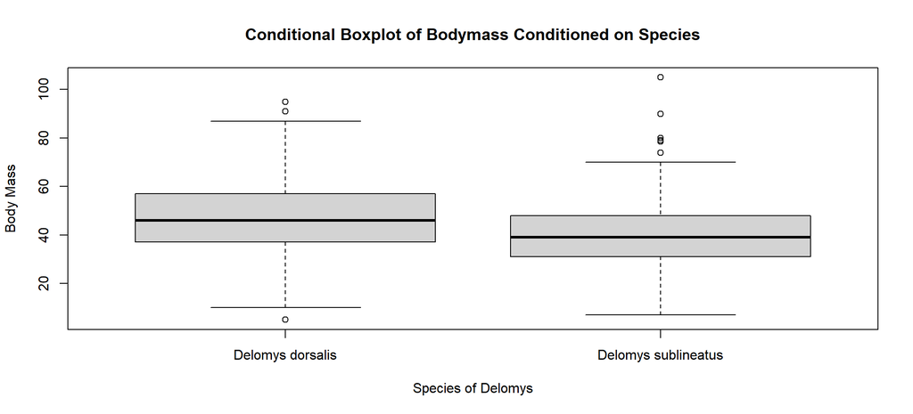

```r
boxplot(body_mass ~ binomial, data = dat_delomys, xlab = "Species of Delomys", ylab = "Body Mass", main = "Conditional Boxplot of Bodymass Conditioned on Species")
```

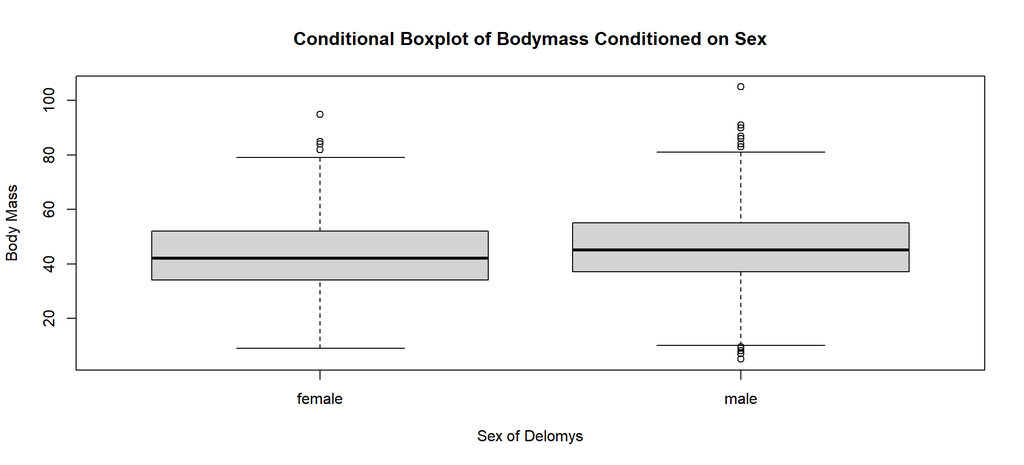

```r
boxplot(body_mass ~ sex, data = dat_delomys, xlab = "Sex of Delomys", ylab = "Body Mass", main = "Conditional Boxplot of Bodymass Conditioned on Sex")
```

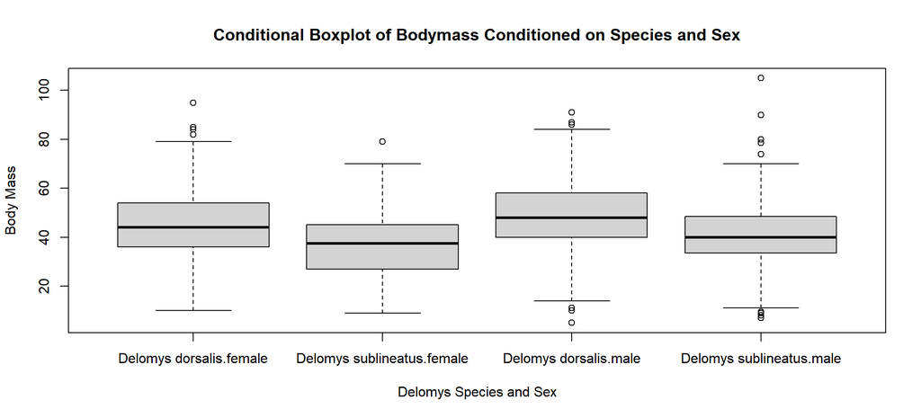

```r
boxplot(body_mass ~ binomial * sex, data = dat_delomys, xlab = "Delomys Species and Sex", ylab = "Body Mass", main = "Conditional Boxplot of Bodymass Conditioned on Species and Sex")
```

Questions:

1. Qualitatively describe the relationship between body mass and length.

The relationship between body mass and length seems to be relatively linear because as Body Mass increases so does Body Length.

2. Quantitatively describe the shapes of the histograms.

3. Using both the histograms and normality tests, do you think the (unconditioned) body masses and body length are normally-distributed?

Using the normality shapiro tests it would seem that both distributions are not normal due to the P values that are smaller than 0.05. I would probably agree with our tests because even if the data looks normally distributed it’s possible that it is actually skewed one way or another.

4. Examine the conditional boxplots. Describe any graphical evidence you see for body mass differences based on species and/or sex.

Looking at the boxplots it seems that the Delomys Dorsalis species is heavier on average than the Delomys Sublineatus species. Also the male sex of Delomys are heavier than the female ones and this holds true for both species.

## Model Building

Next we will be creating some models of regression.

```r
#assorted regression modeling

fit1 = lm(body_length ~ body_mass, data = dat_delomys)
fit2 = lm(body_mass ~ sex, data = dat_delomys)
fit3 = lm(body_mass ~ binomial, data = dat_delomys)
fit4 = lm(body_mass ~ sex + binomial, data = dat_delomys)
fit5 = lm(body_mass ~ sex * binomial, data = dat_delomys)
```

## Model Diagnostics

Do our models fufill the assumption of normality of the residuals?

We can use a graphical approach to test this:

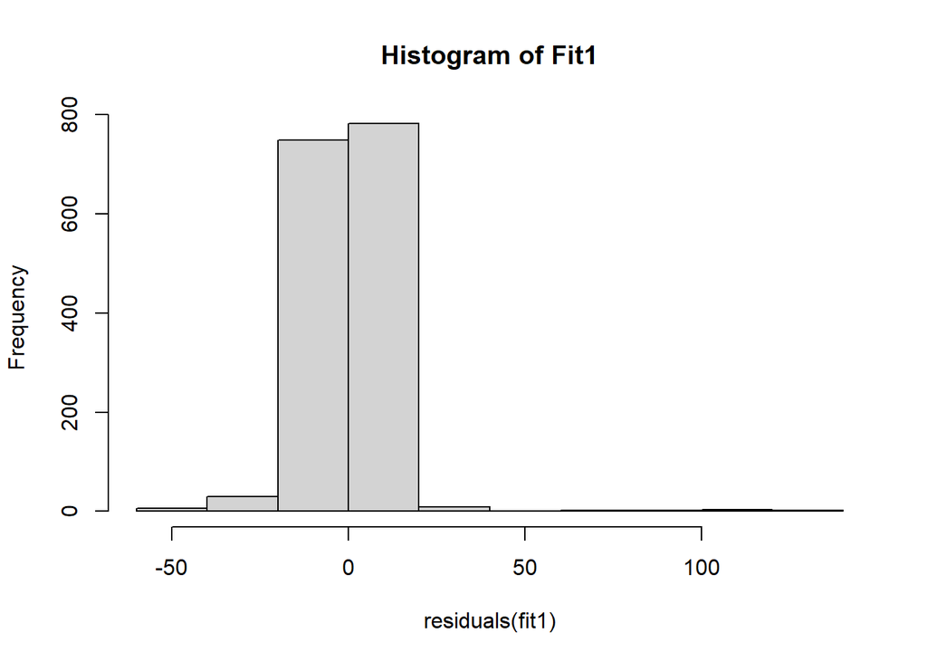

```r
# creating histograms of residuals

hist(residuals(fit1), main = "Histogram of Fit1")
```

```r
shapiro.test(residuals(fit1))
```

```
##
##  Shapiro-Wilk normality test
##
## data:  residuals(fit1)
## W = 0.73462, p-value < 2.2e-16
```

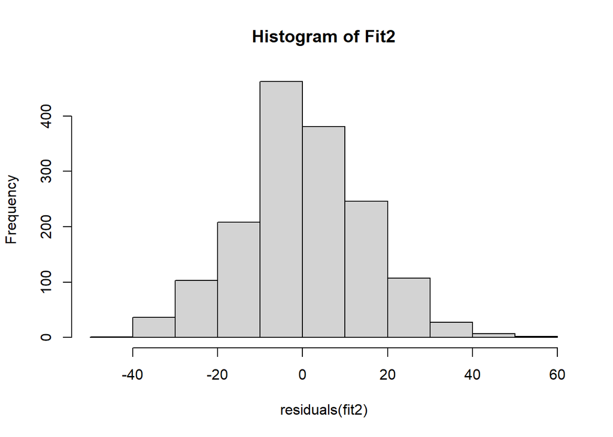

```r
hist(residuals(fit2), main = "Histogram of Fit2")
```

```r
shapiro.test(residuals(fit2))
```

```
##
##  Shapiro-Wilk normality test
##
## data:  residuals(fit2)
## W = 0.99563, p-value = 0.0001541
```

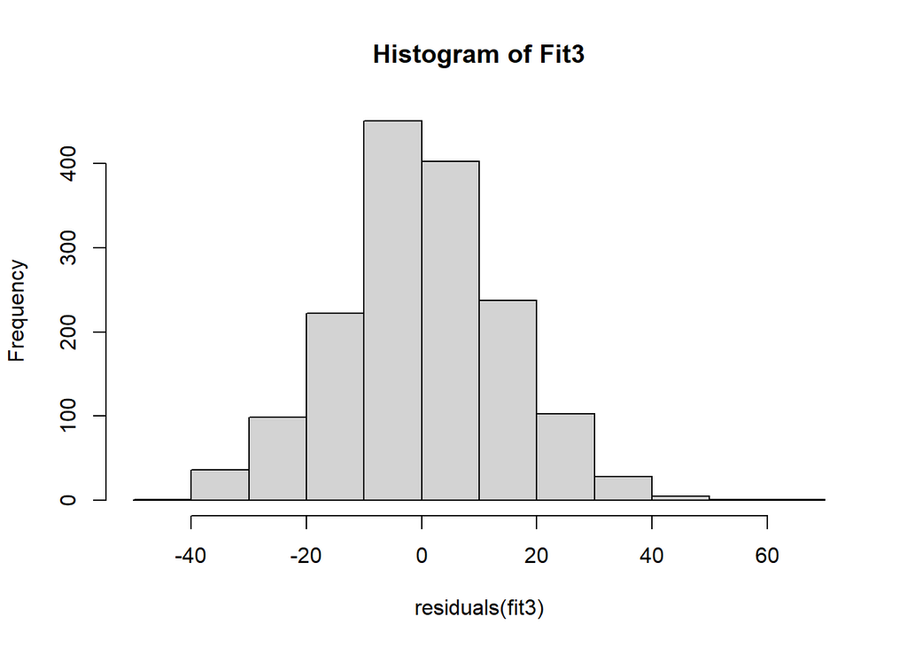

```r
hist(residuals(fit3), main = "Histogram of Fit3")
```

```r
shapiro.test(residuals(fit3))
```

```
##
##  Shapiro-Wilk normality test
##
## data:  residuals(fit3)
## W = 0.99535, p-value = 8.103e-05
```

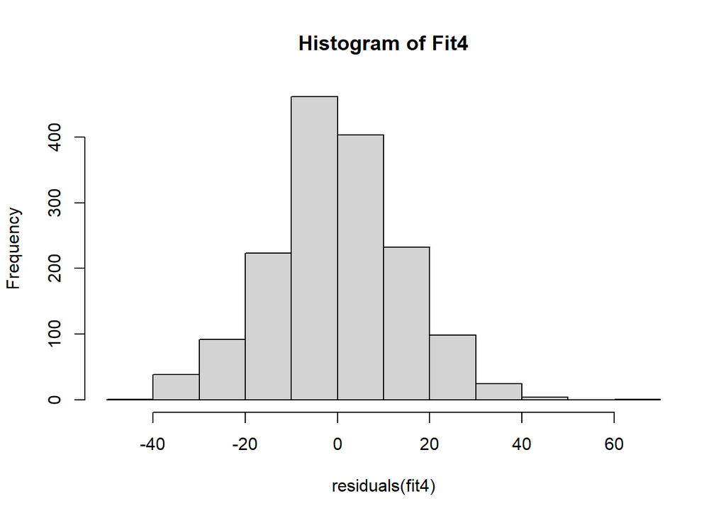

```r
hist(residuals(fit4), main = "Histogram of Fit4")
```

```r
shapiro.test(residuals(fit4))
```

```
##
##  Shapiro-Wilk normality test
##
## data:  residuals(fit4)
## W = 0.99525, p-value = 6.805e-05
```

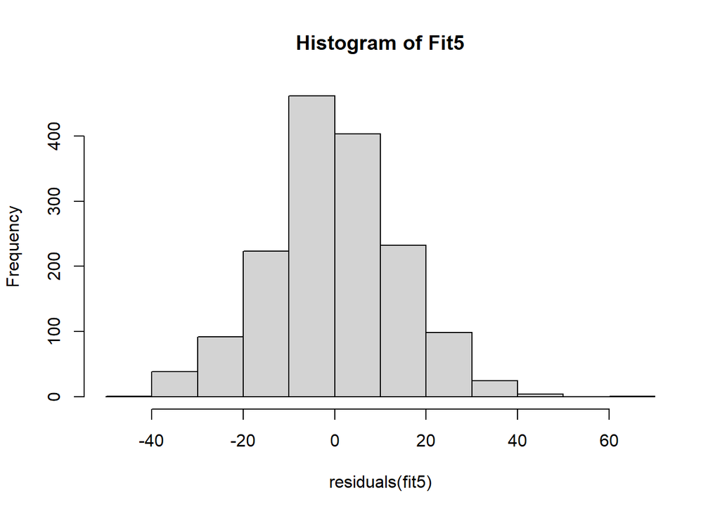

```r
hist(residuals(fit5), main = "Histogram of Fit5")
```

```r
shapiro.test(residuals(fit5))
```

```
##
##  Shapiro-Wilk normality test
##
## data:  residuals(fit5)
## W = 0.99526, p-value = 6.816e-05
```

Questions:

1. What do you conclude about residual normality based on the numerical and graphical diagnostics?

I conclude that the initial shapiro test I conducted was probably correct in that our histograms aren’t normally distributed. Some of the histograms do look like they could be normally distributed but all of our P-values say otherwise.

2. Are violations of the normality assumption equally severe for all the models?

No, Fit1 has much worse violations than all of the other models.

## Model Interpretation

### Coding section

```r
knitr::kable(coef(summary(fit1)), digits = c(4, 2, 2, 20))
```

|  | Estimate | Std. Error | t value | Pr(>\|t\|) |
| --- | --- | --- | --- | --- |
| (Intercept) | 76.1247 | 0.92 | 83.12 | 0 |
| body_mass | 0.8755 | 0.02 | 44.46 | 0 |

```r
knitr::kable(anova(fit1), digits = c(4, 2, 2, 20))
```

|  | Df | Sum Sq | Mean Sq | F value | Pr(>F) |
| --- | --- | --- | --- | --- | --- |
| body_mass | 1 | 269388.9 | 269388.91 | 1976.957 | 0 |
| Residuals | 1583 | 215706.6 | 136.26 | NA | NA |

```r
knitr::kable(coef(summary(fit2)), digits = c(4, 2, 2, 20))
```

|  | Estimate | Std. Error | t value | Pr(>\|t\|) |
| --- | --- | --- | --- | --- |
| (Intercept) | 42.7115 | 0.53 | 80.76 | 0.0000000000 |
| sexmale | 2.7841 | 0.75 | 3.73 | 0.0001951406 |

```r
knitr::kable(anova(fit2), digits = c(4, 2, 2, 20))
```

|  | Df | Sum Sq | Mean Sq | F value | Pr(>F) |
| --- | --- | --- | --- | --- | --- |
| sex | 1 | 3061.68 | 3061.68 | 13.94294 | 2e-04 |
| Residuals | 1578 | 346507.13 | 219.59 | NA | NA |

```r
knitr::kable(coef(summary(fit3)), digits = c(4, 2, 2, 20))
```

|  | Estimate | Std. Error | t value | Pr(>\|t\|) |
| --- | --- | --- | --- | --- |
| (Intercept) | 46.7524 | 0.45 | 103.9 | 0 |
| binomialDelomys sublineatus | -7.6831 | 0.76 | -10.1 | 0 |

```r
knitr::kable(anova(fit3), digits = c(4, 2, 2, 20))
```

|  | Df | Sum Sq | Mean Sq | F value | Pr(>F) |
| --- | --- | --- | --- | --- | --- |
| binomial | 1 | 21289.68 | 21289.68 | 102.0751 | 0 |
| Residuals | 1583 | 330164.45 | 208.57 | NA | NA |

```r
knitr::kable(coef(summary(fit4)), digits = c(4, 2, 2, 20))
```

|  | Estimate | Std. Error | t value | Pr(>\|t\|) |
| --- | --- | --- | --- | --- |
| (Intercept) | 45.0704 | 0.56 | 81.11 | 0.000000e+00 |
| sexmale | 3.7954 | 0.73 | 5.23 | 1.941731e-07 |
| binomialDelomys sublineatus | -8.1935 | 0.76 | -10.77 | 0.000000e+00 |

```r
knitr::kable(anova(fit4), digits = c(4, 2, 2, 20))
```

|  | Df | Sum Sq | Mean Sq | F value | Pr(>F) |
| --- | --- | --- | --- | --- | --- |
| sex | 1 | 3061.68 | 3061.68 | 14.95838 | 1e-04 |
| binomial | 1 | 23727.13 | 23727.13 | 115.92320 | 0e+00 |
| Residuals | 1577 | 322780.00 | 204.68 | NA | NA |

```r
knitr::kable(coef(summary(fit5)), digits = c(4, 2, 2, 20))
```

|  | Estimate | Std. Error | t value | Pr(>\|t\|) |
| --- | --- | --- | --- | --- |
| (Intercept) | 45.0555 | 0.61 | 74.44 | 0.000000e+00 |
| sexmale | 3.8281 | 0.90 | 4.27 | 2.078335e-05 |
| binomialDelomys sublineatus | -8.1417 | 1.13 | -7.22 | 8.218336e-13 |
| sexmale:binomialDelomys sublineatus | -0.0950 | 1.53 | -0.06 | 9.504424e-01 |

```r
knitr::kable(anova(fit5), digits = c(4, 2, 2, 20))
```

|  | Df | Sum Sq | Mean Sq | F value | Pr(>F) |
| --- | --- | --- | --- | --- | --- |
| sex | 1 | 3061.68 | 3061.68 | 14.94893206 | 0.0001 |
| binomial | 1 | 23727.13 | 23727.13 | 115.84997701 | 0.0000 |
| sex:binomial | 1 | 0.79 | 0.79 | 0.00386401 | 0.9504 |
| Residuals | 1576 | 322779.21 | 204.81 | NA | NA |

### Body Length

1. What is the magnitude of the mass/length relationship?

The magnitude of the mass/length relationship is the positive relationship between body length and body mass. In this case the number is 0.87549.

2. What is the expected body length of an an animal that weighs 100g?

The expected body length of an animal that weighs 100g is 76.1247 + 0.8755 * 100 = 163.6747 mm.

3. What is the expected body length of an animal that weighs 0g?

The expected body length of an animal that weighs 0g is 76.1247 mm.

### Body Mass: Model Coefficients

1. What is the base level for sex?

The base level for sex is 42.7115.

2. What is the base level for binomial?

The base level for binomial is 46.7524

3. Which sex is heavier?

The Male sex is heavier.

4. Which species is heavier?

The Delomys Dorsalis species is heavier.

### Body Mass: ANOVA

1. Are sex and species significant predictors for body mass?

I would argue that since both P values are lower than 0.05 then both sex and species are significant predictors for body mass.

2. Is there a significant interaction?

3. Does the significance (as measured by p-value) of either of the main effects (sex and species) differ much between the single-predictor models, the additive model, and the interactive model?

### Model Comparison: Body Mass

```r
AIC(fit2)
```

```
## [1] 13006.8
```

```r
AIC(fit3)
```

```
## [1] 12966.36
```

```r
AIC(fit4)
```

```
## [1] 12896.73
```

```r
AIC(fit5)
```

```
## [1] 12898.72
```

1. Which two models have the lowest AIC?

The two models with the lowest AIC are fit4 and fit5 which are the 2-way additive ANOVA body_mass ~ sex + binomial and the 2-way factorial ANOVA body_mass ~ sex * binomial respectively.

2. Which of the two models with lowest AIC scores would you select?

I would select the 2-way factorial model in this situation because it includes more data to use to make comparisons between the sex and species and Delomys and it has a higher AIC than the additive model. I think that even though the factorial model is slightly more complex the information we can gain from it is more important than the extra effort it takes in interpretation of the model.